# Vektorski podaci: R paket sf

## 🏗️ Koraci u konstrukciji `sf` objekta `grf_ub_sf`

1️⃣ **Određivanje koordinata** 📍  
- Definisali smo **dve tačke**:  
- **Građevinski fakultet**  
- **Univerzitetska biblioteka**

2️⃣ **Kreiranje geometrijskih objekata (`sfg`)**  
- Svaka tačka je kreirana kao **`sfg` (Simple Feature Geometry) objekat**.

3️⃣ **Kombinovanje `sfg` objekata u `sfc` (geometry column)**  
- Više `sfg` objekata su objedinjeni u **geometrijsku kolonu** (`sfc`).  
- U ovom koraku smo definisali i **Koordinatni referentni sistem (`crs`)**.

4️⃣ **Dodavanje atributa i kreiranje `sf` objekta**  
- Dodali smo **atributne podatke** (npr. naziv lokacije)  
- Dobijeni objekat sada pripada **`sf` klasi**, što omogućava prostorne analize.

```
# prvi nivo je je sfg geometrijski primitiv point

grf_point = st_point( c(20.475974, 44.805770)  )
ub_point = st_point(  c(20.4747303 ,44.806143)  )

# kolekcija
grf_ub_sfc = st_sfc(grf_point, ub_point, crs = 4326)

# atributi
atributi = data.frame(
            name = c("Gradjevinski fakultet",
                    "Univerzitetska biblioteka"))

# df objekat, sf lejer
grf_ub_sf = st_sf(atributi, grf_ub_sfc)
```

## Podaci o vulkanima kao obična tabela

```r
# Učitavanje potrebnih paketa
library(sf)
library(tidyverse)

# Učitavanje podataka iz CSV-a, vulkani
vulkani <- read_csv("https://github.com/plotly/datasets/raw/refs/heads/master/volcano_db.csv")

# Pregled prvih redova podataka
str(vulkani)
```

```
spc_tbl_ [1,571 × 10] (S3: spec_tbl_df/tbl_df/tbl/data.frame)
 $ Number      : chr [1:1571] "0803-001" "1505-096" "1402-08=" "0103-004" ...
 $ Volcano Name: chr [1:1571] "Abu" "Acamarachi" "Acatenango" "Acigol-Nevsehir" ...
 $ Country     : chr [1:1571] "Japan" "Chile" "Guatemala" "Turkey" ...
 $ Region      : chr [1:1571] "Honshu-Japan" "Chile-N" "Guatemala" "Turkey" ...
 $ Latitude    : num [1:1571] 34.5 -23.3 14.5 38.6 46.2 ...
 $ Longitude   : num [1:1571] 131.6 -67.6 -90.9 34.5 -121.5 ...
 $ Elev        : num [1:1571] 571 6046 3976 1689 3742 ...
 $ Type        : chr [1:1571] "Shield volcano" "Stratovolcano" "Stratovolcano" "Maar" ...
 $ Status      : chr [1:1571] "Holocene" "Holocene" "Historical" "Holocene" ...
 $ Last Known  : chr [1:1571] "Unknown" "Unknown" "D1" "U" ...
 - attr(*, "spec")=
  .. cols(
  ..   Number = col_character(),
  ..   `Volcano Name` = col_character(),
  ..   Country = col_character(),
  ..   Region = col_character(),
  ..   Latitude = col_double(),
  ..   Longitude = col_double(),
  ..   Elev = col_double(),
  ..   Type = col_character(),
  ..   Status = col_character(),
  ..   `Last Known` = col_character()
  .. )
 - attr(*, "problems")=<externalptr>
```

## Podaci o vulkanima kreiranje sf objekta

```r
# Pretvaranje u prostorni objekat
vulkani_sf <- st_as_sf(vulkani, coords = c("Longitude", "Latitude"), crs = 4326)

# Prikaz podataka u sf formatu
str(vulkani_sf)
```

```
sf [1,571 × 9] (S3: sf/tbl_df/tbl/data.frame)
 $ Number      : chr [1:1571] "0803-001" "1505-096" "1402-08=" "0103-004" ...
 $ Volcano Name: chr [1:1571] "Abu" "Acamarachi" "Acatenango" "Acigol-Nevsehir" ...
 $ Country     : chr [1:1571] "Japan" "Chile" "Guatemala" "Turkey" ...
 $ Region      : chr [1:1571] "Honshu-Japan" "Chile-N" "Guatemala" "Turkey" ...
 $ Elev        : num [1:1571] 571 6046 3976 1689 3742 ...
 $ Type        : chr [1:1571] "Shield volcano" "Stratovolcano" "Stratovolcano" "Maar" ...
 $ Status      : chr [1:1571] "Holocene" "Holocene" "Historical" "Holocene" ...
 $ Last Known  : chr [1:1571] "Unknown" "Unknown" "D1" "U" ...
 $ geometry    :sfc_POINT of length 1571; first list element:  'XY' num [1:2] 131.6 34.5
 - attr(*, "sf_column")= chr "geometry"
 - attr(*, "agr")= Factor w/ 3 levels "constant","aggregate",..: NA NA NA NA NA NA NA NA
  ..- attr(*, "names")= chr [1:8] "Number" "Volcano Name" "Country" "Region" ...
```

## Podaci o vulkanima kreiranje sf plot

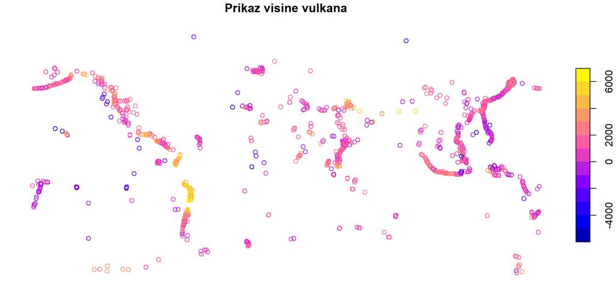

```r
# Prikaz - plot podataka u sf formatu
plot(vulkani_sf["Elev"],
     main = "Prikaz visine vulkana")
```